# Exploration

```python
import json

import matplotlib.pyplot as plt
import seaborn as sns
%matplotlib inline
from matplotlib.pylab import rcParams
rcParams['figure.figsize']= 15,6

import numpy as np
import pandas as pd

import overpy    # Python module to extract POI data of New Delhi from Open Street Map (OSM).
import shapefile as shp
```

```python
# Using overpy module to extract POI data of New Delhi. POI data includes nodes of amenities like -- schools,
# restaurants, hospitals, commercial malls/shopping centers, etc. All the commercial centers in the city will have
# amenities very large in numbers as compared to other outskirts, isolated or poorly developed areas.

api = overpy.Overpass()
res = api.query("""[out:json];
    area[name="New Delhi"][boundary=administrative]->.searchArea;
    (node["amenity"](area.searchArea);
     way["amenity"](area.searchArea);
     relation["amenity"](area.searchArea);
    );
    out center;
    """)
```

```python
# Collecting longitudes and latitudes of amenities within New Delhi for plotting.

coords = []
coords += [(float(node.lon), float(node.lat)) for node in res.nodes]
coords += [(float(way.center_lon), float(way.center_lat))
           for way in res.ways]
coords += [(float(rel.center_lon), float(rel.center_lat))
           for rel in res.relations]
```

```python
c = [(float(node.lon), float(node.lat)) for node in res.nodes]
df_amenity = pd.DataFrame({
    'longitude':[c[i][0] for i in range(len(c))],
    'latitude':[c[i][1] for i in range(len(c))],
    'amenity':[node.tags['amenity'] for node in res.nodes]
})
```

```python
df_amenity.head()
```

|  | longitude | latitude | amenity |
| --- | --- | --- | --- |
| 0 | 77.151895 | 28.533492 | cafe |
| 1 | 77.152001 | 28.533647 | bank |
| 2 | 77.164493 | 28.557309 | cinema |
| 3 | 77.164549 | 28.557846 | bank |
| 4 | 77.163762 | 28.557335 | fast_food |

```python
df_amenity.amenity.unique()
```

```
array(['cafe', 'bank', 'cinema', 'fast_food', 'school', 'fuel', 'parking',
       'restaurant', 'fire_station', 'pharmacy', 'post_box', 'hospital',
       'toilets', 'atm', 'club', 'bus_station', 'embassy',
       'Netaji Nagar Market', 'Suvidha Market, Netaji Nagar',
       'place_of_worship', 'college', 'police', 'Ayurvedic Hospital',
       'House', 'public_building', 'marketplace', 'library', 'bar',
       'kindergarten', 'taxi', 'waste_basket', 'bench', 'doctors',
       'bureau_de_change', 'pub', 'fast_food;bar', 'post_office',
       'theatre', 'community_centre', 'courthouse', 'car_wash',
       'food_court', 'fountain', 'veterinary', 'training',
       'drinking_water', 'bicycle_parking', 'bicycle_rental',
       'vending_machine', 'money_transfer', 'car_rental', 'telephone',
       'waste_disposal', 'bicycle_repair_station', 'nightclub', 'dentist',
       'arts_centre', 'music_school', 'internet_cafe', 'coworking_space',
       'charging_station', 'shelter', 'conference_centre', 'ice_cream',
       'blood_bank', 'payment_terminal'], dtype=object)
```

```python
df = pd.DataFrame({
    'longitude':[coords[i][0] for i in range(len(coords))],
    'latitude':[coords[i][1] for i in range(len(coords))]
})
```

```python
BB = ((df.longitude.min(),   df.longitude.max(),
         df.latitude.min(), df.latitude.max()))
```

```python
BB
```

```
(77.0527553, 77.2444858, 28.489358, 28.6455233)
```

```python
shp_path = "./shapefiles/Delhi_Boundary.shp"
sf = shp.Reader(shp_path,encoding='utf-8')
```

```python
def read_shapefile(sf):
    """
    Read a shapefile into a Pandas dataframe with a 'coords'
    column holding the geometry information. This uses the pyshp
    package
    """
    fields = [x[0] for x in sf.fields][1:]
    records = sf.records()
    shps = [s.points for s in sf.shapes()]
    df = pd.DataFrame(columns=fields, data=records)
    df = df.assign(coords=shps)
    return df
```

```python
df_sh = read_shapefile(sf)
df_sh.shape
```

```
(1, 2)
```

```python
def plot_map(sf,df,BB, x_lim = None, y_lim = None, figsize = (11,9)):

    plt.figure(figsize = figsize)
    id=0
    for shape in sf.shapeRecords():
        x = [i[0] for i in shape.shape.points[:]]
        y = [i[1] for i in shape.shape.points[:]]
        plt.plot(x, y, 'k')

        if (x_lim == None) & (y_lim == None):
            x0 = np.mean(x)
            y0 = np.mean(y)
            plt.text(x0, y0, id, fontsize=10)
        id = id+1

    if (x_lim != None) & (y_lim != None):
        plt.xlim(x_lim)
        plt.ylim(y_lim)

    plt.scatter(df.longitude, df.latitude, zorder=0, alpha= 0.3, c='b', s=7,marker="o")
    #plt.set_title('Plotting Spatial Data on New Delhi Map')
    #plt.set_xlim(BB[0],BB[1])
    #plt.set_ylim(BB[2],BB[3])

    #plt.savefig('delhi_map.png')
```

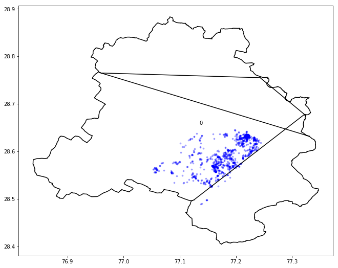

```python
plot_map(sf,df,BB)
```

Here we can see that much of New Delhi's commercial centres are located in central and east south part of the city.  
Now we have to seggregate them by further clustering spatially.

```python
shp1_path = "./shapefiles/Delhi_Wards.shp"
sf1 = shp.Reader(shp1_path,encoding='utf-8')
```

```python
df_sh1 = read_shapefile(sf1)
df_sh1.shape
```

```
(290, 3)
```

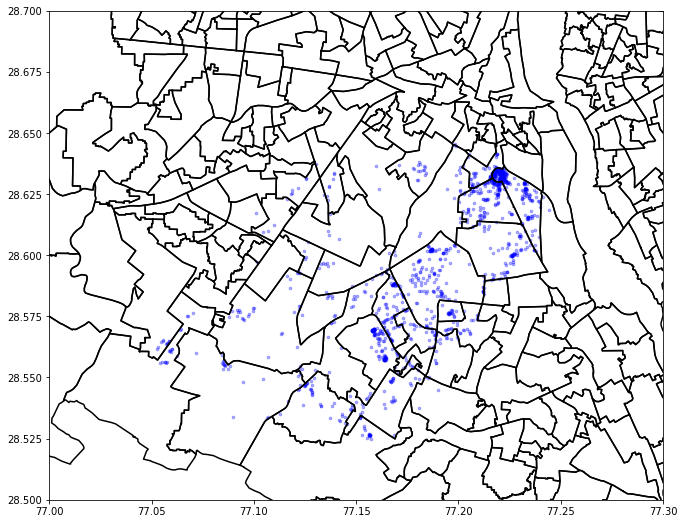

```python
y_lim = (28.5,28.7) # latitude
x_lim = (77, 77.3) # longitude

plot_map(sf1,df,BB,x_lim,y_lim)
```

- Clustering
- cluster-ward identification
- spatial data

Amenities  
'cafe', 'bank', 'cinema', 'fast_food', 'school', 'fuel', 'parking', 'restaurant', 'fire_station', 'pharmacy', 'post_box', 'hospital', 'toilets', 'atm', 'club', 'bus_station', 'embassy', 'Netaji Nagar Market', 'Suvidha Market, Netaji Nagar', 'place_of_worship', 'college', 'police', 'Ayurvedic Hospital', 'House', 'public_building', 'marketplace', 'library', 'bar', 'kindergarten', 'taxi', 'waste_basket', 'bench', 'doctors', 'bureau_de_change', 'pub', 'fast_food;bar', 'post_office', 'theatre', 'community_centre', 'courthouse', 'car_wash', 'food_court', 'fountain', 'veterinary', 'training', 'drinking_water', 'bicycle_parking', 'bicycle_rental', 'vending_machine', 'money_transfer', 'car_rental', 'telephone', 'waste_disposal', 'bicycle_repair_station', 'nightclub', 'dentist', 'arts_centre', 'music_school', 'internet_cafe', 'coworking_space', 'charging_station', 'shelter', 'conference_centre', 'ice_cream', 'blood_bank'

Approach

- Firstly,my approach will be to implement density-based clustering algorithms like DBSCAN,DENCLUE which will give us clusters purely based on how dense the area is in our dataset but things don't end there
- Commercial centres are meant and run in boundaries (wards) so we have to make sure if a person is seeking this data to identify commercial centres based on the current metrices, it's done right.
- Focussing only on density based would be blunder in practical scenario because the algorithm doesnt classifies the difference and availability of all the amenities (assuming an incoming business needs atleast 60-70% of the amenities listed above)

```python
# implementing DBSCAN
from sklearn.cluster import DBSCAN
```

```python
X = np.array(c)
```

```python
# Using DBSCAN algorithm for clustering, a density-based spatial clustering algo.
#All the nodes (amenities) are clustered using their geographical coordinates and density to
#find out the commerical centers.As points are very near to each other, we need to use very small value of
#epsilon to get different smaller clusters.

clustering = DBSCAN(eps=0.008, min_samples=10).fit(X)
```

```python
def plot_map_dbscan(sf,df,clustering, x_lim = None, y_lim = None, figsize = (11,9)):

    plt.figure(figsize = figsize)
    id=0
    for shape in sf.shapeRecords():
        x = [i[0] for i in shape.shape.points[:]]
        y = [i[1] for i in shape.shape.points[:]]
        plt.plot(x, y, 'k')

        if (x_lim == None) & (y_lim == None):
            x0 = np.mean(x)
            y0 = np.mean(y)
            plt.text(x0, y0, id, fontsize=10)
        id = id+1

    if (x_lim != None) & (y_lim != None):
        plt.xlim(x_lim)
        plt.ylim(y_lim)

    #plt.scatter(X[:,0], X[:,1], c=clustering.labels_.astype(float))
    LABEL_COLOR_MAP = {0 : 'salmon',
                   1 : 'blue',
                   2 : 'yellow',
                   3 : 'magenta',
                   4 : 'red',
                   5 : 'green',
                   -1: 'cyan'
                   }
    for l in range(len(LABEL_COLOR_MAP)):
        X = df.loc[df.cluster==l,'longitude'].values
        y = df.loc[df.cluster==l,'latitude'].values

        try:
            plt.scatter(X,y,c=LABEL_COLOR_MAP[l])

        except:
            pass
    plt.scatter(X,y,c=LABEL_COLOR_MAP[-1])

    plt.legend([0,1,2,3,4,5,-1],loc='upper right')
    ax = plt.gca()
    leg = ax.get_legend()
    leg.legendHandles[0].set_color('salmon')
    leg.legendHandles[1].set_color('blue')
    leg.legendHandles[2].set_color('yellow')
    leg.legendHandles[3].set_color('magenta')
    leg.legendHandles[4].set_color('red')
    leg.legendHandles[5].set_color('green')
    leg.legendHandles[6].set_color('cyan')
```

```python
df_amenity['cluster'] = clustering.labels_
```

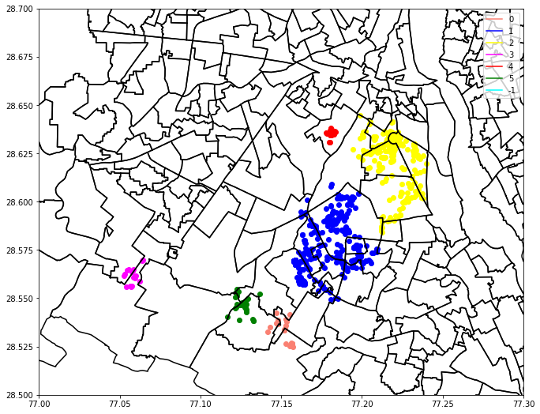

```python
y_lim = (28.5,28.7) # latitude
x_lim = (77, 77.3) # longitude
plot_map_dbscan(sf1,df_amenity,clustering,x_lim,y_lim)
```

```python
clustering.components_
```

```
array([[77.1518947, 28.533492 ],
       [77.152001 , 28.5336472],
       [77.164493 , 28.5573088],
       ...,
       [77.1861058, 28.6021801],
       [77.1860978, 28.6016723],
       [77.1861386, 28.6016518]])
```

```python
from sklearn.metrics import silhouette_samples, silhouette_score
```

```python
silhouette_avg = silhouette_score(X, clustering.labels_.astype(float))
```

```python
#The silhouette ranges from −1 to +1,
#where a high value indicates that the object is well matched to its own cluster and
#poorly matched to neighboring clusters.
silhouette_avg
```

```
0.46388660532672177
```

0.46 is the optimized silhouette score we got on this data with eps=0.008 and min_samples=10  
There's also something known as

##### GeoSilhouette coefficient

identifying which clusters constitute >60% of the amenities and ranking them based on that

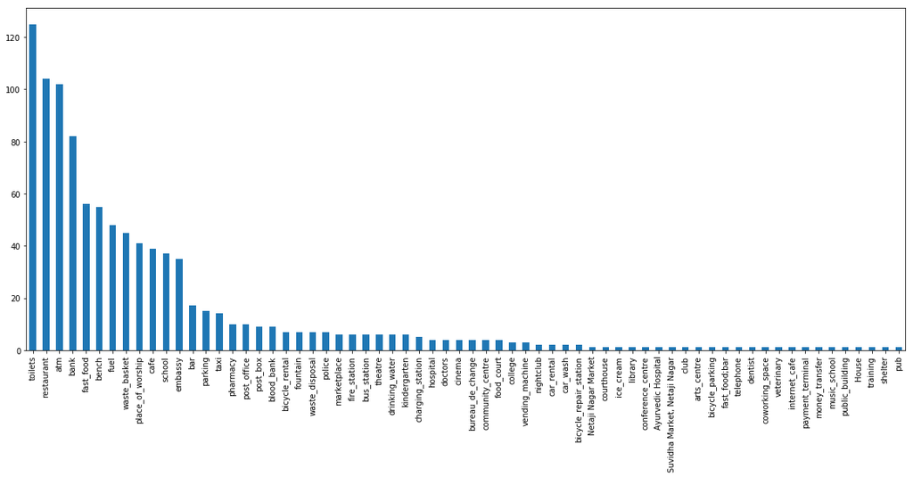

```python
df_amenity.amenity.value_counts().plot(kind='bar',figsize=(20,8))
```

- We will be ranking clusters based on count of amenities provided. It may represent only a hotspot in the city or a commercial centre, to be a commercial centre that too in Delhi may or may not require things listed in the amenities  
  For eg. Jama Masjid market is a big commercial centre for mughal era history and cuisines but it doesn't required to have a car rental service. But for that too we need to dig deep and that will be done in next iteration of this project.

```python
len(clustering.labels_)
```

```
984
```

```python
df_amenity.head()
```

|  | longitude | latitude | amenity | cluster |
| --- | --- | --- | --- | --- |
| 0 | 77.151895 | 28.533492 | cafe | 0 |
| 1 | 77.152001 | 28.533647 | bank | 0 |
| 2 | 77.164493 | 28.557309 | cinema | 1 |
| 3 | 77.164549 | 28.557846 | bank | 1 |
| 4 | 77.163762 | 28.557335 | fast_food | 1 |

```python
amenity_0 = df_amenity.loc[df_amenity.cluster==0,'amenity'].values
amenity_1 = df_amenity.loc[df_amenity.cluster==1,'amenity'].values
amenity_01 = df_amenity.loc[df_amenity.cluster==-1,'amenity'].values
amenity_2 = df_amenity.loc[df_amenity.cluster==2,'amenity'].values
amenity_3 = df_amenity.loc[df_amenity.cluster==3,'amenity'].values
amenity_4 = df_amenity.loc[df_amenity.cluster==4,'amenity'].values
amenity_5 = df_amenity.loc[df_amenity.cluster==5,'amenity'].values
```

```python
gt = len(df_amenity.amenity.unique())
```

```python
print('cluster-0 contains : {:0.03f}% of amenities'.format((len(set(amenity_0))/gt)*100))
print('cluster-1 contains : {:0.03f}% of amenities'.format((len(set(amenity_1))/gt)*100))
print('cluster-01 contains: {:0.03f}% of amenities'.format((len(set(amenity_01))/gt)*100))
print('cluster-2 contains : {:0.03f}% of amenities'.format((len(set(amenity_2))/gt)*100))
print('cluster-3 contains : {:0.03f}% of amenities'.format((len(set(amenity_3))/gt)*100))
print('cluster-4 contains : {:0.03f}% of amenities'.format((len(set(amenity_4))/gt)*100))
print('cluster-5 contains : {:0.03f}% of amenities'.format((len(set(amenity_5))/gt)*100))
```

```
cluster-0 contains : 25.758% of amenities
cluster-1 contains : 74.242% of amenities
cluster-01 contains: 42.424% of amenities
cluster-2 contains : 66.667% of amenities
cluster-3 contains : 12.121% of amenities
cluster-4 contains : 9.091% of amenities
cluster-5 contains : 16.667% of amenities
```

It's evident that cluster-1 is the most evident one followed by 2 and 0 and further. There must be noise in this and we'll discover that also

#### Points to ponder

- which cluster lies in which ward numbers?
- Noise identification in above discovered clusters
- which cluster needs further clustering?
- key takeaways from those particular clusters in their respective wards like any special kind of place with special feature (historical,political,cultural,geographical)
- map filling with those cluster number in their wards and saving the shapefile

```python
# cluster to ward number mapping can be done by comparing the data from mcd and and clusters formed here
```

Now we need to further cluster 0,1 and 2 since they are spread in multiple wards which isn't ideal because market and commercial centres are known usually by their places and not inter-ward thing.

We will now cluster markets based on density of available data in each ward and visualize it

```python
def plot_map_fill(ids, sf, colors,cluster_no,x_lim = None,
                          y_lim = None,
                          figsize = (11,9),
                          ):

    plt.figure(figsize = figsize)
    fig, ax = plt.subplots(figsize = figsize)
    for shape in sf.shapeRecords():
        x = [i[0] for i in shape.shape.points[:]]
        y = [i[1] for i in shape.shape.points[:]]
        ax.plot(x, y, 'k')

    for id,color in zip(ids,colors):
        shape_ex = sf.shape(id)
        x_lon = np.zeros((len(shape_ex.points),1))
        y_lat = np.zeros((len(shape_ex.points),1))
        for ip in range(len(shape_ex.points)):
            x_lon[ip] = shape_ex.points[ip][0]
            y_lat[ip] = shape_ex.points[ip][1]
        ax.fill(x_lon,y_lat, color)

        x0 = np.mean(x_lon)
        y0 = np.mean(y_lat)
        plt.text(x0, y0, (cluster_no,id), fontsize=10)

        if (x_lim != None) & (y_lim != None):
            plt.xlim(x_lim)
            plt.ylim(y_lim)
```

```python
def plot_map_fill_multiples_ids(title, comuna, sf, cluster_no,
                                               x_lim = None,
                                               y_lim = None,
                                               figsize = (11,9),
                                               color = 'r'):

    plt.figure(figsize = figsize)
    fig, ax = plt.subplots(figsize = figsize)
    fig.suptitle(title, fontsize=16)
    for shape in sf.shapeRecords():
        x = [i[0] for i in shape.shape.points[:]]
        y = [i[1] for i in shape.shape.points[:]]
        ax.plot(x, y, 'k')

    for id in comuna:
        shape_ex = sf.shape(id)
        x_lon = np.zeros((len(shape_ex.points),1))
        y_lat = np.zeros((len(shape_ex.points),1))
        for ip in range(len(shape_ex.points)):
            x_lon[ip] = shape_ex.points[ip][0]
            y_lat[ip] = shape_ex.points[ip][1]
        ax.fill(x_lon,y_lat, color)

        x0 = np.mean(x_lon)
        y0 = np.mean(y_lat)
        plt.text(x0, y0, (cluster_no,id), fontsize=10)

    if (x_lim != None) & (y_lim != None):
        plt.xlim(x_lim)
        plt.ylim(y_lim)
```

Let us analyze three major clusters of our data starting with cluster-2

```python
#take cluster-2
```

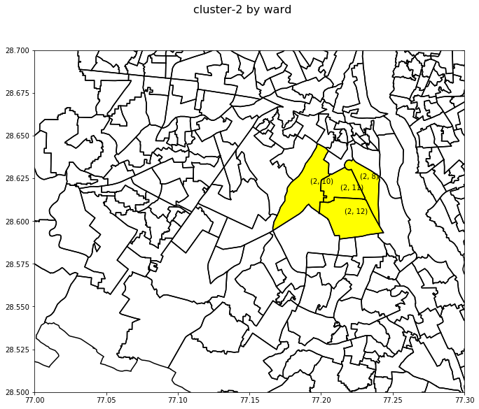

```python
# cluster-2
y_lim = (28.5,28.7) # latitude
x_lim = (77, 77.3) # longitude
comuna_id = [10,11,12,8]
plot_map_fill_multiples_ids("cluster-2 by ward", comuna_id, sf1, cluster_no=2,
                                       x_lim=x_lim,
                                       y_lim=y_lim,
                                       figsize = (11,9),
                                       color = 'yellow')
```

- So, further clustering on the basis of density will reveal more significant wards belonging to that cluster
- Heatmap will be able to show this feature of significant clusters

#### Cluster Significance by ward

can be determined by

- amenities as well as
- historical significance
- population
- economics

```python
# so just be looking at the clusters we can decide which gets more share
```

```python
ward_data_c2 = pd.DataFrame({
    'id':[10,11,12,8],
    'population':[62890,67952,45702,55209],
})
```

```python
ward_data_c2
```

|  | id | population |
| --- | --- | --- |
| 0 | 10 | 62890 |
| 1 | 11 | 67952 |
| 2 | 12 | 45702 |
| 3 | 8 | 55209 |

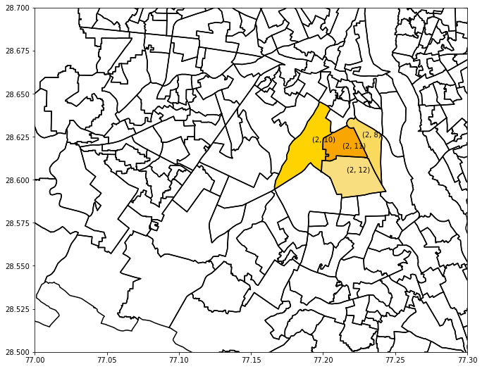

```python
plot_map_fill(ids=ward_data_c2.id.values,
              sf = sf1,
              x_lim=x_lim,
              y_lim=y_lim,
              cluster_no=2,
              colors=["#FFD300","#F9A602","#F8DE7E","#FADA5E"])
#plt.text(x0, y0, cluster_id[0], fontsize=10)
```

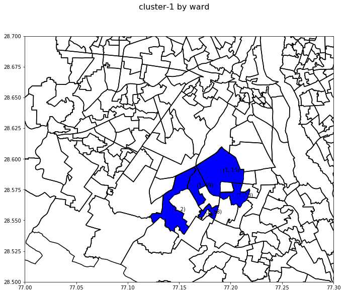

```python
# cluster-1
y_lim = (28.5,28.7) # latitude
x_lim = (77, 77.3) # longitude
comuna_id = [15,69,13,68,2]
plot_map_fill_multiples_ids("cluster-1 by ward", comuna_id, sf1, cluster_no=1,
                                       x_lim=x_lim,
                                       y_lim=y_lim,
                                       figsize = (11,9),
                                       color = 'blue')
```

Cluster-1 is majorly spread between wards 15,69,13,68,2 which represents area such as  
Janakpuri west,kamla nagar,Tilak Nagar

- So, further clustering on the basis of density will reveal more significant wards belonging to that cluster
- Heatmap will be able to show this feature of significant clusters

#### Cluster Significance by ward

can be determined by

- amenities as well as
- historical significance
- population
- economics

```python
ward_data_c1 = pd.DataFrame({
    'id':[15,69,13,68,2],
    'population':[53542,59839,69734,47435,49968],
})
```

```python
ward_data_c1
```

|  | id | population |
| --- | --- | --- |
| 0 | 15 | 53542 |
| 1 | 69 | 59839 |
| 2 | 13 | 69734 |
| 3 | 68 | 47435 |
| 4 | 2 | 49968 |

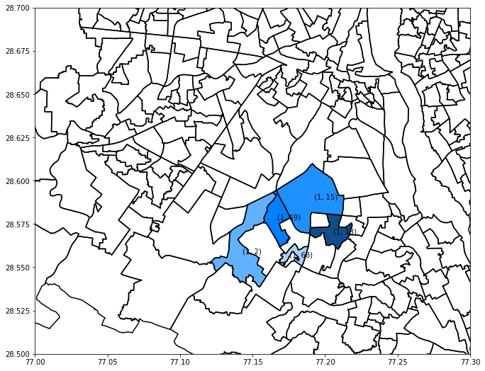

```python
plot_map_fill(ids=ward_data_c1.id.values,
              sf = sf1,
              x_lim=x_lim,
              y_lim=y_lim,
              cluster_no=1,
              colors=["#1E90FF","#007FFF","#104E8B","#A3D2FF","#60B1FF"])
```

Cluster-0 is majorly spread between wards 247,70 which represents area such as  
Chhatarpur,Ram Nagar

- So, further clustering on the basis of density will reveal more significant wards belonging to that cluster
- Heatmap will be able to show this feature of significant clusters

#### Cluster Significance by ward

can be determined by

- amenities as well as
- historical significance
- population
- economics

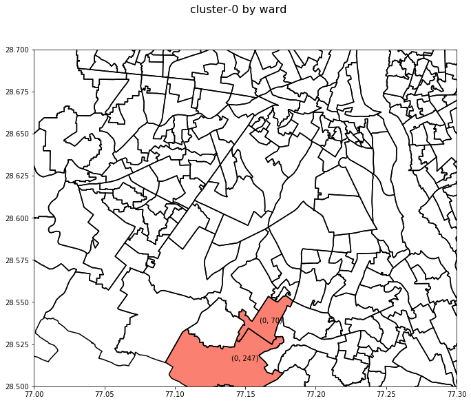

```python
# cluster-0
y_lim = (28.5,28.7) # latitude
x_lim = (77, 77.3) # longitude
comuna_id = [247,70]
plot_map_fill_multiples_ids("cluster-0 by ward", comuna_id, sf1, cluster_no=0,
                                       x_lim=x_lim,
                                       y_lim=y_lim,
                                       figsize = (11,9),
                                       color = 'salmon')
```

```python
ward_data_c0 = pd.DataFrame({
    'id':[247,70],
    'population':[59837,68716],
})
```

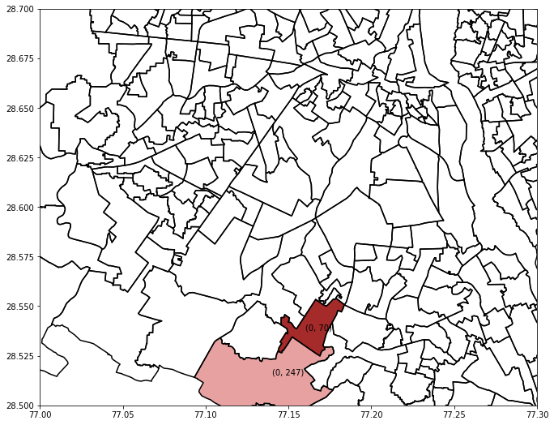

```python
plot_map_fill(ids=ward_data_c0.id.values,
              sf = sf1,
              x_lim=x_lim,
              y_lim=y_lim,
              cluster_no=0,
              colors=["#E7A1A1","#A52A2A"])
```

# Final Thoughts and Conclusions

# Vision

- More analysis can be done once more data about places can be compiled viz Historical,Economical,Population data,Cultural
- Clustering can be improved by employing better state of hyperparameters and Spatial Algorithms that justifies proximity as well as other features